# Project Dice (Exemplar)

Chad Worley

# Summary

I was handed a 3D-printed 6-sided die with sides marked with 1, 2, 3, 4, 5, and 6 pips. Of course, I was immediately suspicious because the dice were 3D-printed, and my suspicions were confirmed because the teacher said that some of the dice might be weighted to have a population mean not equal 3.5. We were instructed to roll 50 rolls to generate confidence intervals of the population mean.

With dice, the idea of a population mean is better phrased as the [expected value](https://en.wikipedia.org/wiki/Expected_value), or the long-run average that is expected after a million rolls. The goal is to make an inference about the expected value based on a sample of 50 rolls.

# Data and formulaic approach

I’ve pasted the raw data here as a comma-separated list:

2, 6, 3, 4, 4, 1, 3, 4, 5, 3, 4, 3, 5, 5, 1, 4, 2, 1, 2, 4, 4, 6, 5, 4, 5, 6, 5, 5, 2, 1, 4, 4, 5, 6, 1, 3, 6, 2, 2, 2, 1, 3, 3, 2, 1, 1, 2, 3, 2, 4

Below are some summary statistics:

$$\text{sample size} = n = 50$$
$$\text{sample mean} = \bar{x} =
3.32$$
$$\text{sample standard
deviation} = s = 1.596$$

These were found in a spreadsheet using `=count()`, `=average()`, and `=stdev()`. That spreadsheet (which also contains the bootstrap resampling analysis) can be found at https://fake.link. From those numbers we can calculate the confidence interval using a formula.
$$\bar{x}\pm \frac{2s}{\sqrt{n}} ~=~ 3.32 \pm
\frac{2\cdot 1.596}{\sqrt{50}}$$

We find the boundaries:
$$3.32 -
\frac{2\cdot 1.596}{\sqrt{50}} = 2.869$$
$$3.32 + \frac{2\cdot 1.596}{\sqrt{50}} =
3.771$$

We can express the confidence interval in interval notation.

$$\text{formulaic confidence interval} =
[2.869,3.771]$$

We can find the margin of error by halving the difference.
$$\text{formulaic margin of error} =
\frac{3.771-2.869}{2} = 0.45$$

It should also be mentioned that the formulaic margin of error is also just $\frac{2s}{\sqrt{n}}$, the quantity that we added to and subtracted from the sample mean to generate the confidence interval.

# Bootstrap

Those rolls were put in a spreadsheet in cell range A1:A50. To resample, with replacement, from the sample, I used `=INDEX($A$1:$A$50,RANDBETWEEN(1,50),1)` in cell range D1:BA1000. This is equivalent to 1000 repetitions, where each repetition has 50 values (there are 50 columns and 1000 rows). Notice the 50 is not coincidental, I used 50 columns because the sample had 50 rolls.

For each row I calculated a mean. Although the project description did not require a histogram, I found it helpful to generate a histogram of my resampled means.

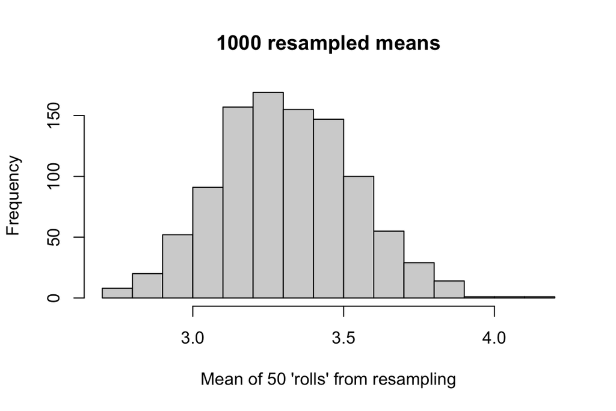

By finding the 2.5th percentile and the 97.5th percentile of these means, I generated my 95% confidence interval.
$$\text{bootstrap confidence interval} =
[2.9,3.76]$$
By halving the difference, I find the margin of error.
$$\text{bootstrap margin of error} =
0.43$$

# Analysis

Both methods (formulaic and bootstrap) produced very similar confidence intervals and margins of error.

A fair die should have an expected value equal to 3.5. My confidence intervals both contained 3.5 (because 3.5 is between the boundaries). So, my conclusion is that two possibilities remain:

- The expected value of my die is, like a fair die, equal to 3.5, or
- With more data, maybe I could show that my die’s expected value is not equal 3.5.

Either way, I can say that I did **not** find a significant difference between my die’s mean and 3.5.